# Music Lyrics over Decades: a NLP study

## Music lyrics affect our well-being

[figure not shown]

2015, Patricia Fox Ransom, University of Pennsylvania

## Music becomes angrier and sadder

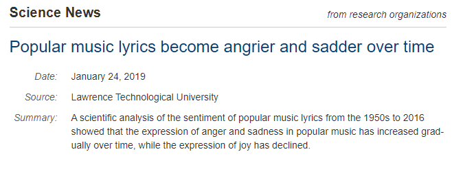

2019, Lawrence Technological University, sciencedaily.com

## Project goals

- How has the sentiment of song lyrics changed over the decades?
- Which were the main sentiments in each decade?
- Which decade has the most positive sentiment?
- Which decade has the most negative sentiment?
- How is the word frequency distribution of each decade?
- How has the vocaboulary changed over decades?
- What is the main topic of each decade?

## Lyrics sentiment over decades

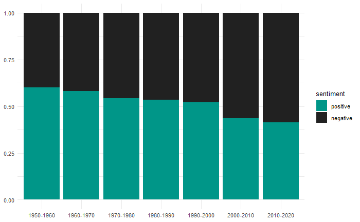

based on BING lexicon: the negative sentiment is growing over time

- The positive sentiment has decreased over time
- From 1970 to 2000, negative and positive sentiments are balanced
- Since the beginning of the twenty-first century, the negative sentiment is predominant

## Analyzing wordclouds

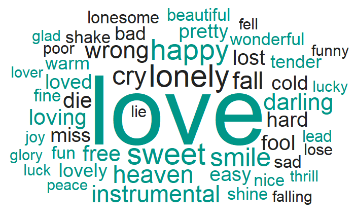

1950-1960 wordcloud

## Analyzing wordclouds

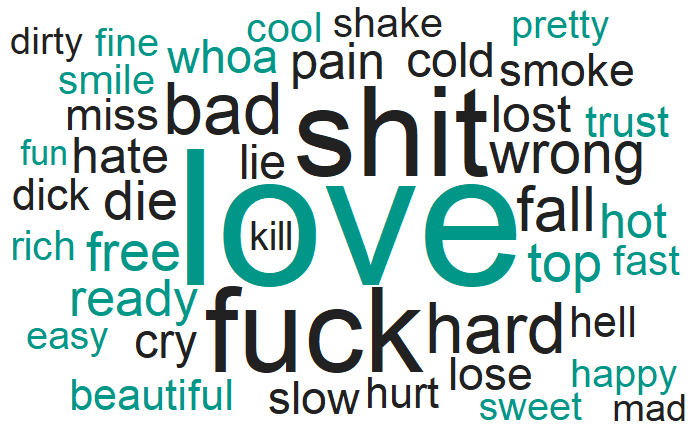

2010-2020 wordcloud

- In 2010-2020 a lot of swearing is present
- An emotional state, related to the negative introspective side of the person emerges

## Sentiment types trend

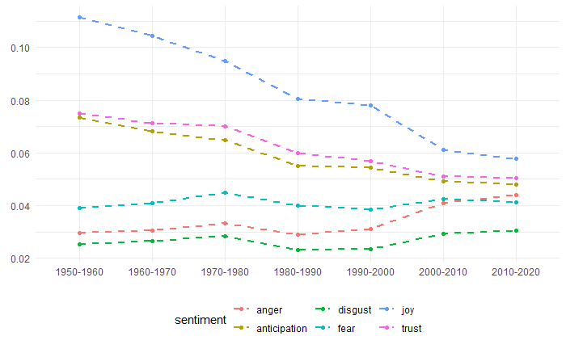

- The anger sentiment grows after the 1990-2000 decade
- Joy, trust and anticipation sentiments decrease significantly
- In the 1970-1980 decade the sentiment of anger slightly increases, maybe due to the popularity of hard rock music during that time

## Term and Document Term Frequency

*Term frequency distributions*

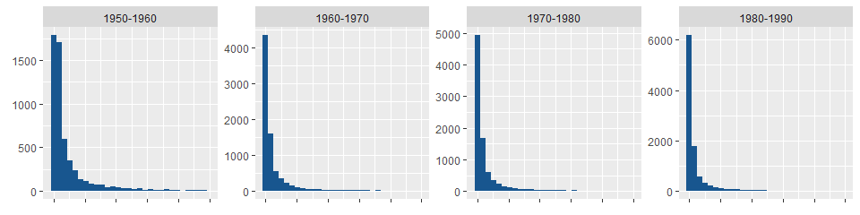

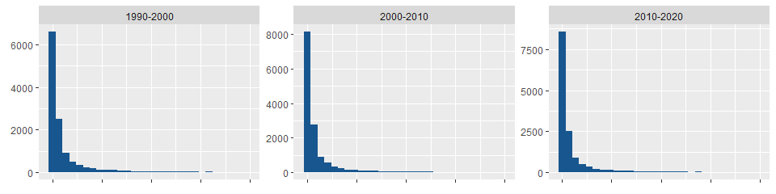

*Term Frequency vs Rank*

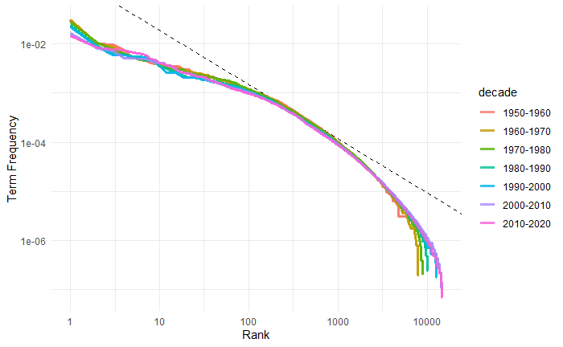

Zip’s law, without stop-words

## Term and Document Term Frequency

*TF-IDF*

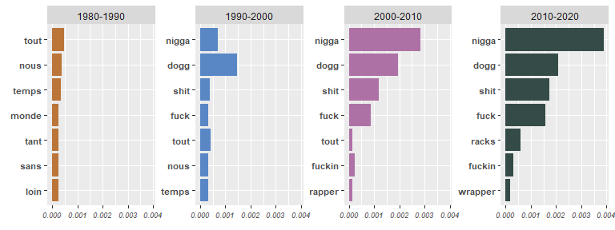

- The 1980-1990 decade is distinguished from the others by the presence of french words
- The next decades present the same words
- Swear words (like nigga, dogg, shit, fuck) increase in frequency over time
- In the last decade an element of vanity emerges with the word “racks”

## Topic modelling

*1950-1960 topics*

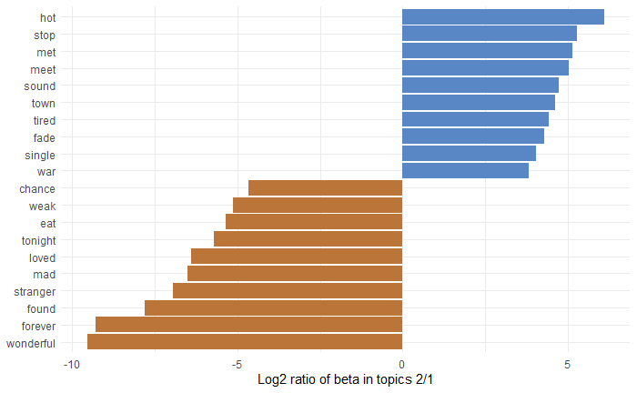

- One of the topics is related to the end of the WW2
- The other one is related to love stories

*1970-1980 topics*

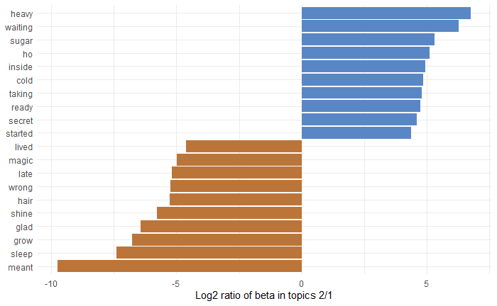

- One relevant topic is related to disco music, exterior style and appereance

*1990-2000 topics*

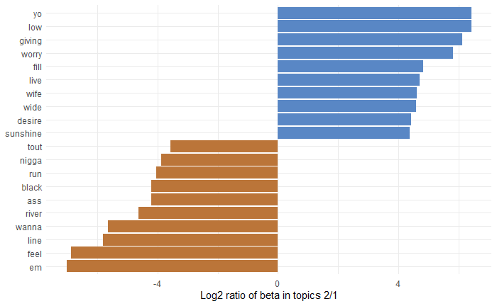

- It’s clear how rap music emerged in this decade

*2010-2020 topics*

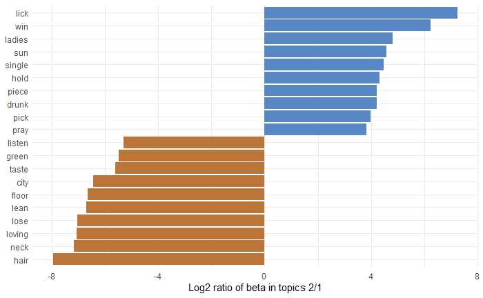

- One of the topics is related to crazy parties
- The other one is related to exterior style and appereance

## Conclusion

- The sentiment of song lyrics has become more and more negative over time
- Differences between the first and last decade are significant
- The first has the most positive sentiment
- Our decade has the most high number of negative sentiment types
- Power law appears even in song lyrics
- In the last decades, the use of swear words has increased
- Also the topics differ in each epoch due to changes in the society